# Análisis de la varianza

# 8 Comparaciones múltiples

Utilizamos el scheffe test del peste agricolae para las 2 combinaciones[4]. Si ejecutamos el test con group=TRUE, ofrece esta información.

```r
comp_scheffe<-scheffe.test(anova2, "ShelveLoc", group=TRUE)
comp_scheffe
```

```
## $statistics
##    MSerror  Df        F     Mean    CV
##   4.971391 394 3.018626 7.409975 30.09
##
## $parameters
##      test    name.t ntr alpha
##   Scheffe ShelveLoc   3  0.05
##
## $means
##           Sales      std   r        se  Min   Max    Q25  Q50     Q75
## Bad    5.522917 2.356349  96 0.2275639 0.37 11.67 4.0525 5.21  7.4625
## Good   9.807647 2.437948  85 0.2418408 3.58 16.27 7.8000 9.54 11.6200
## Medium 7.306575 2.266373 219 0.1506666 0.00 13.36 5.6250 7.38  8.7750
##
## $comparison
## NULL
##
## $groups
##           Sales groups
## Good   9.807647      a
## Medium 7.306575      b
## Bad    5.522917      c
##
## attr(,"class")
## [1] "group"
```

Pero realmente lo que nos interesa es si hay significación entre los grupos, y por eso evaluamos si las letras en los grupos son distintas:

```r
comp_scheffe$groups
```

```
##           Sales groups
## Good   9.807647      a
## Medium 7.306575      b
## Bad    5.522917      c
```

Y aquí se ve cómo las letras son diferentes, entonces la diferencia entre los grupos es significativa. Si utilizamos group=FALSE en la parte $groups aparecerá NULL en cambio nos mostrará el p-value en $comparison. Como indica, es significativo.

```r
comp_scheffe2<-scheffe.test(anova2, "US",  group = FALSE, console = TRUE)
```

```
##
## Study: anova2 ~ "US"
##
## Scheffe Test for Sales
##
## Mean Square Error  : 4.971391
##
## US,  means
##
##        Sales      std   r        se  Min   Max    Q25  Q50    Q75
## No  6.579789 2.228414 142 0.1871091 0.00 12.01 5.0800 6.61 8.1650
## Yes 7.866899 2.877131 258 0.1388127 0.37 16.27 5.7625 7.79 9.9875
##
## Alpha: 0.05 ; DF Error: 394
## Critical Value of F: 3.865169
##
## Comparison between treatments means
##
##          Difference pvalue sig       LCL       UCL
## No - Yes   -1.28711      0 *** -1.745146 -0.829075
```

```r
comp_scheffe2
```

```
## $statistics
##    MSerror  Df        F     Mean    CV
##   4.971391 394 3.865169 7.409975 30.09
##
## $parameters
##      test name.t ntr alpha
##   Scheffe     US   2  0.05
##
## $means
##        Sales      std   r        se  Min   Max    Q25  Q50    Q75
## No  6.579789 2.228414 142 0.1871091 0.00 12.01 5.0800 6.61 8.1650
## Yes 7.866899 2.877131 258 0.1388127 0.37 16.27 5.7625 7.79 9.9875
##
## $comparison
##          Difference pvalue sig       LCL       UCL
## No - Yes   -1.28711      0 *** -1.745146 -0.829075
##
## $groups
## NULL
##
## attr(,"class")
## [1] "group"
```

También podemos utilizar este test post-hoc donde indica que:

Bad:Yes-Bad:No

Medium:No-Good:No

Medium:Yes-Good:No

Medium:Yes-Medium:No

Estas combinaciones No son significativas. El resto sí.

```r
TukeyHSD(anova2)
```

```
##   Tukey multiple comparisons of means
##     95% family-wise confidence level
##
## Fit: aov(formula = Sales ~ ShelveLoc * US, data = df)
##
## $ShelveLoc
##                  diff       lwr       upr p adj
## Good-Bad     4.284730  3.503495  5.065966     0
## Medium-Bad   1.783659  1.141584  2.425733     0
## Medium-Good -2.501072 -3.171409 -1.830735     0
##
## $US
##            diff       lwr      upr   p adj
## Yes-No 1.120046 0.6620106 1.578082 2.2e-06
##
## $`ShelveLoc:US`
##                             diff         lwr         upr     p adj
## Good:No-Bad:No        2.42406863  0.72171089  4.12642637 0.0007766
## Medium:No-Bad:No      1.49323529  0.19532758  2.79114301 0.0136206
## Bad:Yes-Bad:No        0.36565465 -0.99698878  1.72829808 0.9726282
## Good:Yes-Bad:No       5.34585824  3.97926478  6.71245171 0.0000000
## Medium:Yes-Bad:No     2.34745752  1.12222385  3.57269118 0.0000011
## Medium:No-Good:No    -0.93083333 -2.40874517  0.54707850 0.4645112
## Bad:Yes-Good:No      -2.05841398 -3.59348924 -0.52333872 0.0019764
## Good:Yes-Good:No      2.92178962  1.38320694  4.46037229 0.0000014
## Medium:Yes-Good:No   -0.07661111 -1.49112746  1.33790523 0.9999875
## Bad:Yes-Medium:No    -1.12758065 -2.19669178 -0.05846951 0.0319343
## Good:Yes-Medium:No    3.85262295  2.77848180  4.92676410 0.0000000
## Medium:Yes-Medium:No  0.85422222 -0.03313286  1.74157731 0.0667951
## Good:Yes-Bad:Yes      4.98020360  3.82867771  6.13172948 0.0000000
## Medium:Yes-Bad:Yes    1.98180287  1.00219493  2.96141081 0.0000002
## Medium:Yes-Good:Yes  -2.99840073 -3.98349580 -2.01330566 0.0000000
```

Graficamos

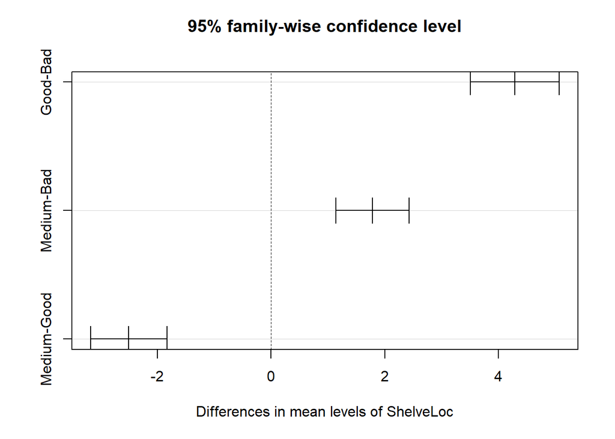

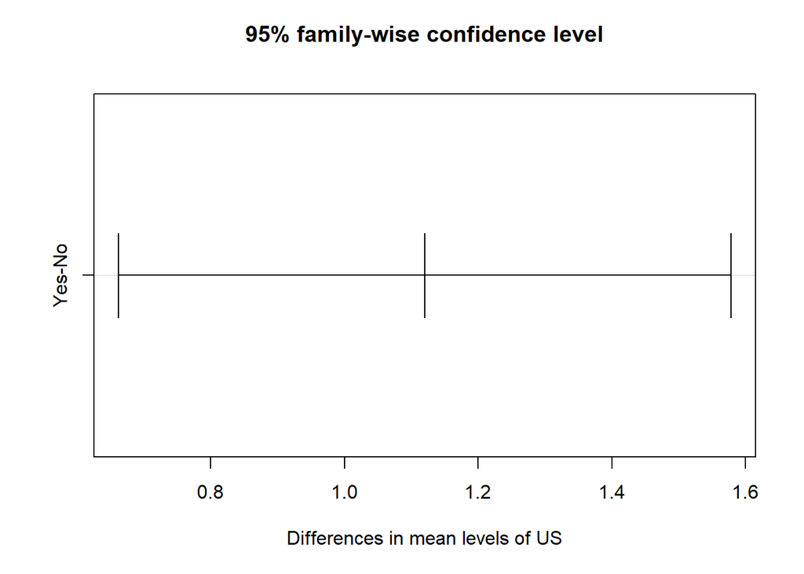

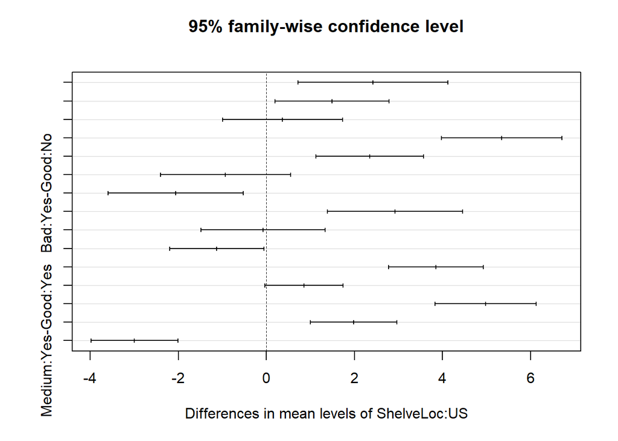

```r
plot(TukeyHSD(anova2))
```

Otra prueba de que se utiliza, a tenor del encontrado en la literatura y tutoriales en internet es la Prueba de Bonferroni.

```r
sld_comp<-LSD.test(anova2, "ShelveLoc", p.adj='bon', console = TRUE)
```

```
##
## Study: anova2 ~ "ShelveLoc"
##
## LSD t Test for Sales
## P value adjustment method: bonferroni
##
## Mean Square Error:  4.971391
##
## ShelveLoc,  means and individual ( 95 %) CI
##
##           Sales      std   r        se      LCL       UCL  Min   Max    Q25
## Bad    5.522917 2.356349  96 0.2275639 5.075525  5.970308 0.37 11.67 4.0525
## Good   9.807647 2.437948  85 0.2418408 9.332187 10.283107 3.58 16.27 7.8000
## Medium 7.306575 2.266373 219 0.1506666 7.010364  7.602786 0.00 13.36 5.6250
##         Q50     Q75
## Bad    5.21  7.4625
## Good   9.54 11.6200
## Medium 7.38  8.7750
##
## Alpha: 0.05 ; DF Error: 394
## Critical Value of t: 2.404246
##
## Groups according to probability of means differences and alpha level( 0.05 )
##
## Treatments with the same letter are not significantly different.
##
##           Sales groups
## Good   9.807647      a
## Medium 7.306575      b
## Bad    5.522917      c
```

```r
sld_comp
```

```
## $statistics
##    MSerror  Df     Mean    CV
##   4.971391 394 7.409975 30.09
##
## $parameters
##         test  p.ajusted    name.t ntr alpha
##   Fisher-LSD bonferroni ShelveLoc   3  0.05
##
## $means
##           Sales      std   r        se      LCL       UCL  Min   Max    Q25
## Bad    5.522917 2.356349  96 0.2275639 5.075525  5.970308 0.37 11.67 4.0525
## Good   9.807647 2.437948  85 0.2418408 9.332187 10.283107 3.58 16.27 7.8000
## Medium 7.306575 2.266373 219 0.1506666 7.010364  7.602786 0.00 13.36 5.6250
##         Q50     Q75
## Bad    5.21  7.4625
## Good   9.54 11.6200
## Medium 7.38  8.7750
##
## $comparison
## NULL
##
## $groups
##           Sales groups
## Good   9.807647      a
## Medium 7.306575      b
## Bad    5.522917      c
##
## attr(,"class")
## [1] "group"
```

Como indica “Treatments with the same letter are not significantly different.” entonces cada grupo tiene una letra distinta.

```r
sld_comp2<-LSD.test(anova2, "US", p.adj='bon', console = TRUE)
```

```
##
## Study: anova2 ~ "US"
##
## LSD t Test for Sales
## P value adjustment method: bonferroni
##
## Mean Square Error:  4.971391
##
## US,  means and individual ( 95 %) CI
##
##        Sales      std   r        se      LCL      UCL  Min   Max    Q25  Q50
## No  6.579789 2.228414 142 0.1871091 6.211932 6.947646 0.00 12.01 5.0800 6.61
## Yes 7.866899 2.877131 258 0.1388127 7.593993 8.139805 0.37 16.27 5.7625 7.79
##        Q75
## No  8.1650
## Yes 9.9875
##
## Alpha: 0.05 ; DF Error: 394
## Critical Value of t: 1.966003
##
## Groups according to probability of means differences and alpha level( 0.05 )
##
## Treatments with the same letter are not significantly different.
##
##        Sales groups
## Yes 7.866899      a
## No  6.579789      b
```

```r
sld_comp2
```

```
## $statistics
##    MSerror  Df     Mean    CV
##   4.971391 394 7.409975 30.09
##
## $parameters
##         test  p.ajusted name.t ntr alpha
##   Fisher-LSD bonferroni     US   2  0.05
##
## $means
##        Sales      std   r        se      LCL      UCL  Min   Max    Q25  Q50
## No  6.579789 2.228414 142 0.1871091 6.211932 6.947646 0.00 12.01 5.0800 6.61
## Yes 7.866899 2.877131 258 0.1388127 7.593993 8.139805 0.37 16.27 5.7625 7.79
##        Q75
## No  8.1650
## Yes 9.9875
##
## $comparison
## NULL
##
## $groups
##        Sales groups
## Yes 7.866899      a
## No  6.579789      b
##
## attr(,"class")
## [1] "group"
```

Y también sale significativo por el factor US.

Para comparar, ejecutaré el test de scheffe por el factor URBAN

```r
comp_scheffe3<-scheffe.test(anova3, "Urban",  group = TRUE, console = TRUE)
```

```
##
## Study: anova3 ~ "Urban"
##
## Scheffe Test for Sales
##
## Mean Square Error  : 5.445632
##
## Urban,  means
##
##        Sales      std   r        se  Min   Max   Q25  Q50   Q75
## No  7.509237 2.723436 118 0.2148242 0.00 13.91 5.440 7.67 9.320
## Yes 7.368440 2.740159 282 0.1389631 0.37 16.27 5.375 7.40 9.125
##
## Alpha: 0.05 ; DF Error: 394
## Critical Value of F: 3.865169
##
## Groups according to probability of means differences and alpha level( 0.05 )
##
## Means with the same letter are not significantly different.
##
##        Sales groups
## No  7.509237      a
## Yes 7.368440      a
```

```r
comp_scheffe3
```

```
## $statistics
##    MSerror  Df        F     Mean       CV
##   5.445632 394 3.865169 7.409975 31.49252
##
## $parameters
##      test name.t ntr alpha
##   Scheffe  Urban   2  0.05
##
## $means
##        Sales      std   r        se  Min   Max   Q25  Q50   Q75
## No  7.509237 2.723436 118 0.2148242 0.00 13.91 5.440 7.67 9.320
## Yes 7.368440 2.740159 282 0.1389631 0.37 16.27 5.375 7.40 9.125
##
## $comparison
## NULL
##
## $groups
##        Sales groups
## No  7.509237      a
## Yes 7.368440      a
##
## attr(,"class")
## [1] "group"
```

Y comprobamos cómo los grupos (Yes y No) tienen la misma letra, y no son significativamente diferentes.

# 9 Conclusiones

## 9.1 Sobre la base de datos

Hemos trabajado una base de datos sobre 400 observaciones que provienen de una simulación con 14 variables, de las cuales 3 son categóricas. La variable dependiente a estudiar ha sido las ventas “Salas” y las variables factoriales estudiadas han sido “US”, “Urban” y “ShelveLoc”.

## 9.2 Análisis gráfico

He presentado un estudio gráfico inicial para visualizar las distribuciones de las variables y he detectado 3 outliers que en otras pruebas se han reiterado, pero no se han tratado. He tomado la decisión de no eliminar las observaciones.

## 9.3 Contraste medias

He presentado el contraste de medias de la variable US y ha salido significativamente diferente, y esto se ha repetido en los estudios factoriales posteriores. También he demostrado que la variable OS presenta heterocedasticidad y debe compararse mediante test no paramétricos.

## 9.4 Regresión

En la regresión lineal con la variable dependiendo “Salas” la variable ShelveLoc se presenta como muy influyente con un coeficiente muy importante en la clase “good”. Se presentan varios modelos pero no mejoramos la bondad expresada en $R^2$. He buscado formas para mejorar el modelo mediante la discretización de la variable Advertising, pero no ha dado el resultado esperado.

## 9.5 Estudio factorial

Una vez realizado tanto una anova de una vía como de dos vías, como variable dependiendo “Salas” y las variables factoriales, “ShelveLoc”, “Urban” y “US” se aprecia una diferencia significativa entre las medias de ShelveLoc y US . La variable Urban no presenta diferencia significativa.

## 9.6 Relación resultados ANOVA y Regresión lineal

De las variables estudiadas, las más influyentes en la regresión han sido: Price - una relación negativa respecto al precio de la competencia, lógico pero con poca variabilidad. Advertising - Es la variable continua más inluyente en la regresión lineal.

De las variables factoriales ShelveLoc es la más influyente con mucha diferencia. Si comparamos con la variable *eta Squared* del modelo anova, se confirma este hecho. Una conclusión es que las variables con mayor significancia en un modelo anova podrían ser las más influyentes en un modelo de regresión lineal, respecto a los otros factores, y además podrían ser las más discriminantes.

# 10 Bibliografía

[1] Wikipedia https://es.wikipedia.org/wiki/Criterio_de_informaci%C3%B3n_de_Akaike

[2] Link. http://imaging.mrc-cbu.cam.ac.uk/statswiki/FAQ/effectSize.

[3] Anova – Type I/II/III SS explained https://mcfromnz.wordpress.com/2011/03/02/anova-type-iiiiii-ss-explained/

[4] https://leaffisherylabdotcom.files.wordpress.com/2016/06/scheffe-test-in-r.pdf